# 420115

# ปฏิบัติการฟิสิกส์อย่างสังเขป

# การทดลองที่3

## การวัดความเร่งเนื่องจากแรงโน้มถ่วง

## วัตถุประสงค์

1. เพื่อศึกษาการแกว่งของลูกตุ้มนาฬิกาอย่างง่ายและลุกตุ้มนาฬิกาฟิสิกัล
2. เพื่อวัดค่าความเร่งโน้มถ่วงของโลก จากคาบการแกว่งของลูกตุ้มนาฬิกาอย่างง่าย
3. เพื่อวัดค่าความเร่งโน้มถ่วงของโลก จากคาบการแกว่งของลูกตุ้มนาฬิกาฟิสิกัล

# การเคลื่อนที่แบบฮาร์มอนิก

- การเคลื่อนที่แบบฮาร์มอนิกเป็นการเคลื่อนที่กลับไปกลับมาผ่านตำแหน่งสมดุล โดย การกระจัดของวัตถุเป็นฟังก์ชันไซน์หรือโคไซน์ ซึ่งเป็นฟังก์ชันฮาร์โมนิก จึงเรียกว่าการเคลื่อนที่ แบบฮาร์โมนิก การเคลื่อนที่ที่ง่ายที่สุดของการเคลื่อนที่แบบฮาร์มอนิก เรียกว่า การเคลื่อนที่ แบบฮาร์มอนิก อย่างง่าย

[figure not shown]

#### ตอนที่1: ลูกตุ้มนาฬิกาอย่างง่าย(A Simple Pendulum)

- วัดค่าความเร่งโน้มถ่วงของโลก,g , จากคาบการแกว่งของลูกตุ้มนาฬิกาอย่างง่าย

[figure not shown]

## ทฤษฎี

- ลูกตุ้มนาฬิกาอย่างง่าย เป็นโมเดลทางคณิตศาสตตร์ ประกอบด้วยลุุูกตุ้มมวล m ขนาดเล็กมากๆ (จุด)ห้อยแขวนไว้ด้วยเชือกที่ไม่มีมวล ถ้าดึงลูกตุ้มให้เคลื่อนที่ออกไปจากตำแหน่งสมดุล จนเส้นเชือกทำมุม θ น้อยๆ กับ แนวดิ่งแล้วปล่อย ลูกตุ้มจะเคลื่อนที่กลับไปกลับมาผ่านตำแหน่งสมดุล โดยมีคาบการแกว่งคงที่

[figure not shown]

คาบเวลาของการแกว่ง,T ($s$), จะมีค่าตามความสัมพันธ์:

> $T~=~2~\pi~\sqrt{\frac{L}{g}} $

เมื่อ **g** เป็นค่าความเร่งจากแรงโน้มถ่วงของโลก ($m/s^{2}$) และ **L** เป็นความยาวของเส้นเชือก ($m$)

> $T^2~=~4~\pi^2\frac{L}{g} $

หากเขียนความสัมพันธ์โดยใช้กราฟเส้นตรงที่มี ความชัน=$slope$, $y=t^2$ และ $x=L$

> $y~=~slope~x $

เมื่อเปรียบเทียบสมการข้างบน ค่าความเร่งจากแรงโน้มถ่วง, g, จะหาได้จาก

> $g~=~4\pi^2\left ({\frac{L}{T^2}} \right ) ~=~ \frac{ 4 \pi^2}{slope} $

> $slope~=~\frac{T^2}{L} $

### อุปกรณ์การทดลอง

[figure not shown]

1. เสาตั้ง
2. ลูกตุ้ม
3. เชือก
4. ไม้เมตร
5. นาฬิกาจับเวลา
6. ฐานตั้งและแกนหมุน
7. ไม้เมตรที่เจาะรู
8. เครื่องชั่งมวล

### วิธีการทดลอง

[figure not shown]

#### ผลการทดลอง: ภาพแสดงนาฬิกาจับเวลา เมื่อลูกคุ้มเคลื่อนที่ไป 10 รอบของการแกว่ง

- ท่ี่ความยาวเชือก $L=60.00$ cm

[figure not shown]

- ท่ี่ความยาวเชือก $L=70.00$ cm

[figure not shown]

- ท่ี่ความยาวเชือก $L=80.00$ cm

[figure not shown]

- ท่ี่ความยาวเชือก $L=90.00$ cm

[figure not shown]

- ท่ี่ความยาวเชือก $L=100.00$ cm

[figure not shown]

### ตารางบันทึกผล

[figure not shown]

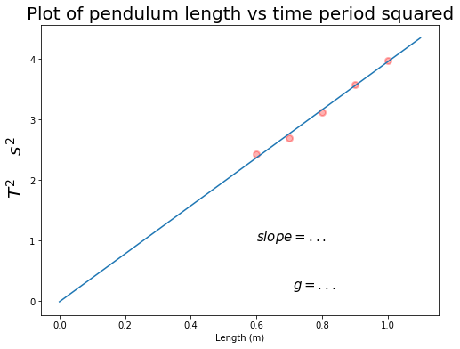

```python
# ตัวอย่างการเขียนกราฟ การทดลอง
plotLab3()
```

```python
#  สาธิตปฏิบัติการที่ 3 รายวิชา 420115 ตอนที่ 1.1
YouTubeVideo(id[0],560,315,rel=0)
```

[video not shown]

```python
#สาธิตปฏิบัติการที่ ตอนที่ 1.2(การแกว่งที่ระยะ 60 cm)
YouTubeVideo(id[1],560,315,rel=0)
```

[video not shown]

#### ตอนที่2: ลูกตุ้มนาฬิกาฟิสิกัล(Physical Pendulum)

- วัดค่าความเร่งจากแรงโน้มถ่วงของโลก,g ,จากคาบการแกว่งของลูกตุ้มนาฬิกาฟิสิกัล

[figure not shown]

## ทฤษฏี

- ใช้อธิบายการแกว่งของวัตถุแข็งเกร็ง ที่ไม่สามารถโมเดลด้วยจุดมวล m หากแขวนวัตถุที่จุดหมุน O ขณะอยู่นิ่ง จุดศูนย์กลางมวลของวัตถุ (จุด C.M.) จะอยู่ในแนวดิ่งใต้จุด O เป็นระยะ h และโมเมนต์ความเฉื่อยของวัตถุรอบแกนที่ผ่านจุด O เป็น I

[figure not shown]

หากเราแกว่งลูกตุ้มนาฬิกาฟิสิกัลเป็นมุมเล็กๆ คาบเวลาของการแกว่ง,T ($s$), จะมีค่าตามความสัมพันธ์:

> $T~=~2~\pi~\sqrt{\frac{I}{mgh}} $
- $g$ เป็นค่าความเร่งจากแรงโน้มถ่วงของโลก ($m/s^{2}$)
- $I$ เป็นโมเมนต์ความเฉื่อยของวัตถุ ($kg m^2$)
- $h$ เป็น ระยะหว่างจุดหมุน O และ จุดศูนย์กลางมวลของวัตถุ($m$)

> $T^2~=~4~\pi^2\frac{I}{mgh} $

ค่าความเร่งจากแรงโน้มถ่วง, g, จะหาได้จาก

> $g~=~4\pi^2\left ({\frac{I}{mT^2h}} \right )$

โมเมนต์ความเฉื่อยของไม้เมตรยาว L รอบแกนที่ผ่านจุด O คำนวณได้จาก

> $I~=~ I_{CM} + mh^2$

> $I~=~ \frac{1}{12}mL^2 + mh^2$

เมื่อ $I_{CM}~=~ \frac{1}{12}mL^2$คือโมเมนต์ความเฉื่อยของไม้เมตรยาว L รอบแกนที่ผ่านจุดจุดศูนย์กลางมวล

### วิธีการทดลอง

[figure not shown]

1. ชั่งมวลของไม้เมตร
2. ระยะห่างจากจุดหมุน(รูบนไม้เมตร)ถึงจุดกึ่งกลางของไม้เมตร(จุดที่ความยาว 50 cmเป็นระยะ h
3. จัดอุปกรณ์ การทดลองดังรูป
4. จัดให้ไม้เมตรแกว่งโดยมีมุมแกว่งไม่เกิน 10 องศา
5. จับเวลาที่ไม้เมตรแกว่งครบ 10 รอบ คำนวณค่าคาบการแกว่งเฉลี่ยของลูกตุ้ม (T)
6. คํานวณหาค่า g จากสมการข้างล่าง และ หาเปอร์เซนต์ความแตกต่างจากค่า g ที่ได้จากการทดลองในตอนที่ 1
7. สรุปผลการทดลอง

#### สมการค่า $g$ ของการทดลองตอนที่2

> $g~=~4\pi^2\left ({\frac{\frac{1}{12}mL^2 + mh^2}{mT^2h}} \right )$
- $L$: ความยาวของไม้เมตร
- $h$: ระยะจากจุดหมุน(จุดที่เจาะรู)ถึงจุดศูนย์กลางของไม้เมตร

#### ผลการทดลอง ตอนที่ 2

- ภาพเครื่องชั่งมวลของไม้เมตร

[figure not shown]

  จากภาพอ่านค่ามวลของไม้เมตรได้ 105.01 กรัม
- ภาพจุดที่เจาะรูสำหรับแขวนของไม้เมตร (จุดหมุนม ใช้สำหรับคำนาณค่า h)

[figure not shown]

  เป็น จากภาพอ่านค่าจุดที่เจาะรูบนไม้เมตรเป็น 6.45 cm ดังนั้นระยะ $h~=~50.00-6.45 cm =43.55 cm$
- ภาพแสดงนาฬิกาจับเวลา เมื่อไม้เมตรเคลื่อนที่ไป 10 รอบของการแกว่ง

[figure not shown]

  จากภาพอ่านค่าเวลาในการแกว่งไม้เมตร 10 รอบเป็น 15.68 s ดังนั้น $T=\frac{15.68}{10} ~=~ 1.57$ s

### ตารางบันทึกผล ตอนที่ 2

[figure not shown]

```python
# สาธิตปฏิบัติการที่ ตอนที่ 2.1
YouTubeVideo(id[2],560,315,rel=0)
```

[video not shown]

```python
# สาธิตปฏิบัติการที่ 3 ตอนที่ 2.2
YouTubeVideo(id[3],560,315,rel=0)
```

[video not shown]

```python
# สาธิตปฏิบัติการที่ 3 ตอนที่ 2.3 (การวัดมวลไม้เมตร)
YouTubeVideo(id[4],560,315,rel=0)
```

[video not shown]

```python
#jupyter nbconvert DJExp3revised.ipynb --to slide --to slides --post serve --SlidesExporter.reveal_scroll=True --SlidesExporter.reveal_theme=sky
```